# Ryan Richardson Quiz 1

Ryan Richardson

22/10/2020

## Question 1

### 1a

```r
summary(mpgData)
```

```
##  manufacturer          model               displ            year
##  Length:234         Length:234         Min.   :1.600   Min.   :1999
##  Class :character   Class :character   1st Qu.:2.400   1st Qu.:1999
##  Mode  :character   Mode  :character   Median :3.300   Median :2004
##                                        Mean   :3.472   Mean   :2004
##                                        3rd Qu.:4.600   3rd Qu.:2008
##                                        Max.   :7.000   Max.   :2008
##       cyl           trans               drv                 cty
##  Min.   :4.000   Length:234         Length:234         Min.   : 9.00
##  1st Qu.:4.000   Class :character   Class :character   1st Qu.:14.00
##  Median :6.000   Mode  :character   Mode  :character   Median :17.00
##  Mean   :5.889                                         Mean   :16.86
##  3rd Qu.:8.000                                         3rd Qu.:19.00
##  Max.   :8.000                                         Max.   :35.00
##       hwy             fl               class
##  Min.   :12.00   Length:234         Length:234
##  1st Qu.:18.00   Class :character   Class :character
##  Median :24.00   Mode  :character   Mode  :character
##  Mean   :23.44
##  3rd Qu.:27.00
##  Max.   :44.00
```

```r
head(mpgData)
```

```
## # A tibble: 6 x 11
##   manufacturer model displ  year   cyl trans      drv     cty   hwy fl    class
##   <chr>        <chr> <dbl> <int> <int> <chr>      <chr> <int> <int> <chr> <chr>
## 1 audi         a4      1.8  1999     4 auto(l5)   f        18    29 p     compa~
## 2 audi         a4      1.8  1999     4 manual(m5) f        21    29 p     compa~
## 3 audi         a4      2    2008     4 manual(m6) f        20    31 p     compa~
## 4 audi         a4      2    2008     4 auto(av)   f        21    30 p     compa~
## 5 audi         a4      2.8  1999     6 auto(l5)   f        16    26 p     compa~
## 6 audi         a4      2.8  1999     6 manual(m5) f        18    26 p     compa~
```

```r
mpgData$manufacturer = as.factor(mpgData$manufacturer)
mpgData$model = as.factor(mpgData$model)
mpgData$cyl = as.factor(mpgData$cyl)
mpgData$drv = as.factor(mpgData$drv)
mpgData$fl = as.factor(mpgData$fl)
mpgData$class = as.factor(mpgData$class)
mpgData$trans = as.factor(mpgData$trans)


mpgData$avgMpg = (mpgData$cty + mpgData$hwy) / 2
mpgData = mpgData[, !names(mpgData) %in% c("cty", "hwy")]
```

### 1b

Dataset is 234 observations with, originally, 11 variables, 12 with average mpg, this then drops to 10 when we remove cty and hwy as they are directly tied to avg mpg.

```r
names(mpgData)
```

```
##  [1] "manufacturer" "model"        "displ"        "year"         "cyl"
##  [6] "trans"        "drv"          "fl"           "class"        "avgMpg"
```

```r
dim(mpgData)
```

```
## [1] 234  10
```

```r
summary(mpgData)
```

```
##      manufacturer                 model         displ            year
##  dodge     :37    caravan 2wd        : 11   Min.   :1.600   Min.   :1999
##  toyota    :34    ram 1500 pickup 4wd: 10   1st Qu.:2.400   1st Qu.:1999
##  volkswagen:27    civic              :  9   Median :3.300   Median :2004
##  ford      :25    dakota pickup 4wd  :  9   Mean   :3.472   Mean   :2004
##  chevrolet :19    jetta              :  9   3rd Qu.:4.600   3rd Qu.:2008
##  audi      :18    mustang            :  9   Max.   :7.000   Max.   :2008
##  (Other)   :74    (Other)            :177
##  cyl           trans    drv     fl             class        avgMpg
##  4:81   auto(l4)  :83   4:103   c:  1   2seater   : 5   Min.   :10.50
##  5: 4   manual(m5):58   f:106   d:  5   compact   :47   1st Qu.:15.50
##  6:79   auto(l5)  :39   r: 25   e:  8   midsize   :41   Median :20.50
##  8:70   manual(m6):19           p: 52   minivan   :11   Mean   :20.15
##         auto(s6)  :16           r:168   pickup    :33   3rd Qu.:23.50
##         auto(l6)  : 6                   subcompact:35   Max.   :39.50
##         (Other)   :13                   suv       :62
```

### Question 1C

We needed to change Manufactureer, Model, Cylinders, Drive Train, Fuel Type, Car Class, and Transmission to categorical variables.

There may be an argument for converting year to a categorical variable as well, but I chose not to make this change initially to see how the model turned out

### Question 1D

```r
lMod = lm(avgMpg ~ ., data = mpgData)

stepMod = stepAIC(lMod, direction="both")
```

```
## Start:  AIC=151.61
## avgMpg ~ manufacturer + model + displ + year + cyl + trans +
##     drv + fl + class
##
##
## Step:  AIC=151.61
## avgMpg ~ manufacturer + model + displ + year + cyl + trans +
##     fl + class
##
##
## Step:  AIC=151.61
## avgMpg ~ model + displ + year + cyl + trans + fl + class
##
##         Df Sum of Sq    RSS    AIC
## - trans  9     20.92 293.38 150.92
## <none>               272.46 151.61
## - class  2      6.25 278.71 152.92
## - displ  1      8.13 280.59 156.49
## - cyl    3     52.23 324.69 186.65
## - year   1     49.78 322.24 188.87
## - model 33    316.29 588.75 265.91
## - fl     4    406.10 678.56 357.13
##
## Step:  AIC=150.92
## avgMpg ~ model + displ + year + cyl + fl + class
##
##         Df Sum of Sq    RSS    AIC
## - class  2      4.56 297.94 150.52
## <none>               293.38 150.92
## + trans  9     20.92 272.46 151.61
## - displ  1      7.83 301.20 155.08
## - cyl    3     52.33 345.71 183.33
## - year   1     74.92 368.30 202.14
## - model 33    322.82 616.20 258.57
## - fl     4    416.71 710.08 349.75
##
## Step:  AIC=150.52
## avgMpg ~ model + displ + year + cyl + fl
##
##         Df Sum of Sq     RSS    AIC
## <none>                297.94 150.52
## + class  2      4.56  293.38 150.92
## + trans  9     19.22  278.71 152.92
## - displ  1      7.97  305.90 154.70
## - cyl    3     49.91  347.85 180.77
## - year   1     81.81  379.75 205.30
## - fl     4    416.53  714.47 347.20
## - model 37   1138.13 1436.07 444.56
```

```r
summary(stepMod)
```

```
##
## Call:
## lm(formula = avgMpg ~ model + displ + year + cyl + fl, data = mpgData)
##
## Residuals:
##     Min      1Q  Median      3Q     Max
## -5.8909 -0.4819  0.0041  0.4847  5.1745
##
## Coefficients:
##                               Estimate Std. Error t value Pr(>|t|)
## (Intercept)                 -275.61764   41.46160  -6.648 3.17e-10 ***
## modela4                        6.32612    0.84857   7.455 3.25e-12 ***
## modela4 quattro                4.30888    0.82646   5.214 4.88e-07 ***
## modela6 quattro                4.49662    0.99395   4.524 1.08e-05 ***
## modelaltima                    6.40118    0.75425   8.487 6.41e-15 ***
## modelc1500 suburban 2wd        1.09289    0.86699   1.261 0.209041
## modelcamry                     5.80305    0.72073   8.052 9.28e-14 ***
## modelcamry solara              5.71142    0.72247   7.905 2.25e-13 ***
## modelcaravan 2wd               2.65919    0.64971   4.093 6.33e-05 ***
## modelcivic                     8.88164    0.79026  11.239  < 2e-16 ***
## modelcorolla                  10.09008    0.83963  12.017  < 2e-16 ***
## modelcorvette                  7.01040    0.95263   7.359 5.69e-12 ***
## modeldakota pickup 4wd        -0.39444    0.68939  -0.572 0.567899
## modeldurango 4wd              -0.68398    0.76171  -0.898 0.370363
## modelexpedition 2wd           -0.39173    0.95197  -0.411 0.681179
## modelexplorer 4wd              0.14616    0.74291   0.197 0.844246
## modelf150 pickup 4wd          -0.39319    0.74077  -0.531 0.596201
## modelforester awd              2.76748    0.77124   3.588 0.000425 ***
## modelgrand cherokee 4wd       -0.66019    0.72051  -0.916 0.360699
## modelgrand prix                6.14328    0.78121   7.864 2.88e-13 ***
## modelgti                       5.15383    0.83198   6.195 3.63e-09 ***
## modelimpreza awd               3.72743    0.72346   5.152 6.50e-07 ***
## modeljetta                     5.92186    0.75563   7.837 3.39e-13 ***
## modelk1500 tahoe 4wd          -1.18790    0.96032  -1.237 0.217642
## modelland cruiser wagon 4wd   -0.65053    1.08402  -0.600 0.549159
## modelmalibu                    5.28038    0.77336   6.828 1.17e-10 ***
## modelmaxima                    5.78213    0.92087   6.279 2.32e-09 ***
## modelmountaineer 4wd          -0.10320    0.83119  -0.124 0.901322
## modelmustang                   3.90715    0.68566   5.698 4.64e-08 ***
## modelnavigator 2wd             0.05205    0.96562   0.054 0.957071
```

[output cut: 8 more lines]

```
## displ                         -0.70724    0.31627  -2.236 0.026520 *
## year                           0.14841    0.02071   7.166 1.73e-11 ***
## cyl5                          -1.76096    0.80649  -2.183 0.030245 *
## cyl6                          -2.01458    0.39333  -5.122 7.49e-07 ***
## cyl8                          -2.53833    0.76822  -3.304 0.001142 **
## fld                            7.79600    1.50609   5.176 5.81e-07 ***
## fle                           -4.94608    1.43747  -3.441 0.000715 ***
## flp                           -1.87257    1.36387  -1.373 0.171400
## flr                           -0.60703    1.34836  -0.450 0.653090
## ---
## Signif. codes:  0 '***' 0.001 '**' 0.01 '*' 0.05 '.' 0.1 ' ' 1
##
## Residual standard error: 1.262 on 187 degrees of freedom
## Multiple R-squared:  0.9499, Adjusted R-squared:  0.9375
## F-statistic: 77.02 on 46 and 187 DF,  p-value: < 2.2e-16
```

### Question 1E

```r
bestMainEffects = lm(formula = avgMpg ~ model + displ + year + cyl + fl, data = mpgData)
summary(bestMainEffects)
```

```
##
## Call:
## lm(formula = avgMpg ~ model + displ + year + cyl + fl, data = mpgData)
##
## Residuals:
##     Min      1Q  Median      3Q     Max
## -5.8909 -0.4819  0.0041  0.4847  5.1745
##
## Coefficients:
##                               Estimate Std. Error t value Pr(>|t|)
## (Intercept)                 -275.61764   41.46160  -6.648 3.17e-10 ***
## modela4                        6.32612    0.84857   7.455 3.25e-12 ***
## modela4 quattro                4.30888    0.82646   5.214 4.88e-07 ***
## modela6 quattro                4.49662    0.99395   4.524 1.08e-05 ***
## modelaltima                    6.40118    0.75425   8.487 6.41e-15 ***
## modelc1500 suburban 2wd        1.09289    0.86699   1.261 0.209041
## modelcamry                     5.80305    0.72073   8.052 9.28e-14 ***
## modelcamry solara              5.71142    0.72247   7.905 2.25e-13 ***
## modelcaravan 2wd               2.65919    0.64971   4.093 6.33e-05 ***
## modelcivic                     8.88164    0.79026  11.239  < 2e-16 ***
## modelcorolla                  10.09008    0.83963  12.017  < 2e-16 ***
## modelcorvette                  7.01040    0.95263   7.359 5.69e-12 ***
## modeldakota pickup 4wd        -0.39444    0.68939  -0.572 0.567899
## modeldurango 4wd              -0.68398    0.76171  -0.898 0.370363
## modelexpedition 2wd           -0.39173    0.95197  -0.411 0.681179
## modelexplorer 4wd              0.14616    0.74291   0.197 0.844246
## modelf150 pickup 4wd          -0.39319    0.74077  -0.531 0.596201
## modelforester awd              2.76748    0.77124   3.588 0.000425 ***
## modelgrand cherokee 4wd       -0.66019    0.72051  -0.916 0.360699
## modelgrand prix                6.14328    0.78121   7.864 2.88e-13 ***
## modelgti                       5.15383    0.83198   6.195 3.63e-09 ***
## modelimpreza awd               3.72743    0.72346   5.152 6.50e-07 ***
## modeljetta                     5.92186    0.75563   7.837 3.39e-13 ***
## modelk1500 tahoe 4wd          -1.18790    0.96032  -1.237 0.217642
## modelland cruiser wagon 4wd   -0.65053    1.08402  -0.600 0.549159
## modelmalibu                    5.28038    0.77336   6.828 1.17e-10 ***
## modelmaxima                    5.78213    0.92087   6.279 2.32e-09 ***
## modelmountaineer 4wd          -0.10320    0.83119  -0.124 0.901322
## modelmustang                   3.90715    0.68566   5.698 4.64e-08 ***
## modelnavigator 2wd             0.05205    0.96562   0.054 0.957071
```

[output cut: 8 more lines]

```
## displ                         -0.70724    0.31627  -2.236 0.026520 *
## year                           0.14841    0.02071   7.166 1.73e-11 ***
## cyl5                          -1.76096    0.80649  -2.183 0.030245 *
## cyl6                          -2.01458    0.39333  -5.122 7.49e-07 ***
## cyl8                          -2.53833    0.76822  -3.304 0.001142 **
## fld                            7.79600    1.50609   5.176 5.81e-07 ***
## fle                           -4.94608    1.43747  -3.441 0.000715 ***
## flp                           -1.87257    1.36387  -1.373 0.171400
## flr                           -0.60703    1.34836  -0.450 0.653090
## ---
## Signif. codes:  0 '***' 0.001 '**' 0.01 '*' 0.05 '.' 0.1 ' ' 1
##
## Residual standard error: 1.262 on 187 degrees of freedom
## Multiple R-squared:  0.9499, Adjusted R-squared:  0.9375
## F-statistic: 77.02 on 46 and 187 DF,  p-value: < 2.2e-16
```

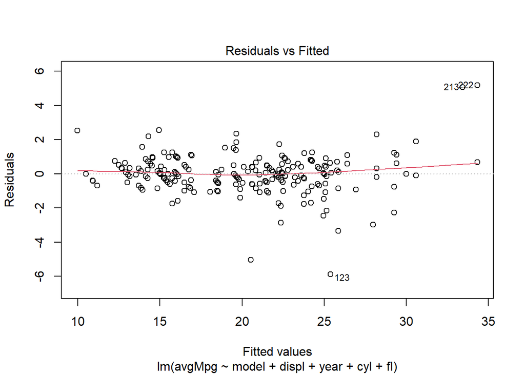

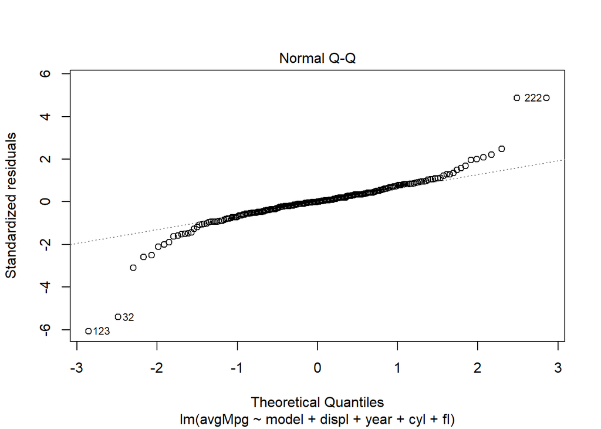

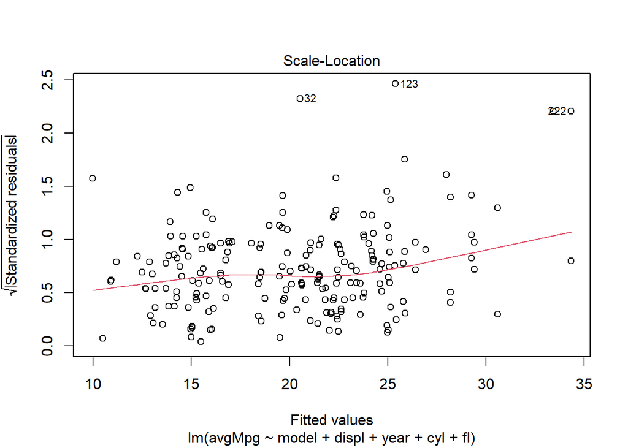

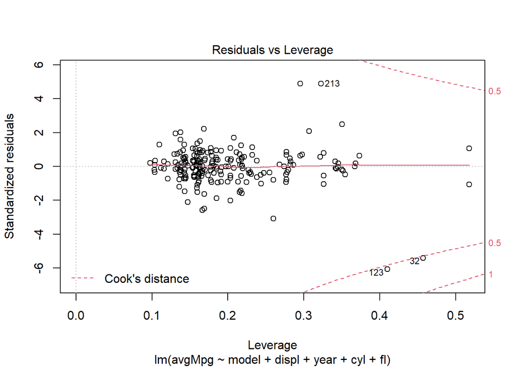

```r
plot(bestMainEffects)
```

### Question 1F

Looking at the inital graphs, significance of the coefficients provided by Step AIC, and adj-rsquared, the overall model apears to be a decent fit. Residuals vs Fitted is mostly linear which leads me to believe that linear regression was not a vad choice, and there is not much clustering of the data, despite the number of categorical variables introduced which tels me there is no over-powering effect caused by any one category.

The QQ plot however has tails that may suggest some of the dat is not normally distributed. However, it is mostly linear, which makes me believe the heavy tails are resulting from a few outliers that are marked on the graph.

The Scale-Location graph is not really linear, despite have a relatively even spread throughout the increase. This could mean that the data is heteroskedastic, but i don’t think it’s extrem enough to warrant concern.

Lastly, the residuals vs levereage plot is not too concerning as all values are at or below a cooks’ distance of 0.5, which should mean that the extreme values are not having too large of an effect on our overal goodness of fit.

### Question 1G

To speed this up I made a smaller dataframe based on our previous best model, otherwise the compute time was too long.

```r
bestMainDf = data.frame(mpgData$avgMpg, mpgData$model, mpgData$displ, mpgData$year,mpgData$cyl, mpgData$fl)
lModInteractions = lm(formula = mpgData.avgMpg ~ .^2, data = bestMainDf)

stepModInteractions = stepAIC(lModInteractions, direction="both")
```

```
## Start:  AIC=-28.53
## mpgData.avgMpg ~ (mpgData.model + mpgData.displ + mpgData.year +
##     mpgData.cyl + mpgData.fl)^2
##
##
## Step:  AIC=-28.53
## mpgData.avgMpg ~ mpgData.model + mpgData.displ + mpgData.year +
##     mpgData.cyl + mpgData.fl + mpgData.model:mpgData.displ +
##     mpgData.model:mpgData.year + mpgData.model:mpgData.cyl +
##     mpgData.model:mpgData.fl + mpgData.displ:mpgData.year + mpgData.displ:mpgData.cyl +
##     mpgData.displ:mpgData.fl + mpgData.year:mpgData.cyl + mpgData.year:mpgData.fl
##
##
## Step:  AIC=-28.53
## mpgData.avgMpg ~ mpgData.model + mpgData.displ + mpgData.year +
##     mpgData.cyl + mpgData.fl + mpgData.model:mpgData.displ +
##     mpgData.model:mpgData.year + mpgData.model:mpgData.cyl +
##     mpgData.model:mpgData.fl + mpgData.displ:mpgData.year + mpgData.displ:mpgData.cyl +
##     mpgData.displ:mpgData.fl + mpgData.year:mpgData.cyl
##
##
## Step:  AIC=-28.53
## mpgData.avgMpg ~ mpgData.model + mpgData.displ + mpgData.year +
##     mpgData.cyl + mpgData.fl + mpgData.model:mpgData.displ +
##     mpgData.model:mpgData.year + mpgData.model:mpgData.cyl +
##     mpgData.model:mpgData.fl + mpgData.displ:mpgData.year + mpgData.displ:mpgData.fl +
##     mpgData.year:mpgData.cyl
##
##                               Df Sum of Sq    RSS     AIC
## - mpgData.model:mpgData.cyl   16    5.8109 63.780 -38.174
## - mpgData.model:mpgData.fl    11    4.8942 62.863 -31.562
## - mpgData.displ:mpgData.fl     1    0.0240 57.993 -30.431
## - mpgData.year:mpgData.cyl     2    0.8765 58.845 -29.016
## <none>                                     57.969 -28.528
## - mpgData.displ:mpgData.year   1    1.1015 59.070 -26.123
## - mpgData.model:mpgData.displ 23   14.5069 72.476 -22.265
## - mpgData.model:mpgData.year  26   17.9379 75.907 -17.441
##
## Step:  AIC=-38.17
## mpgData.avgMpg ~ mpgData.model + mpgData.displ + mpgData.year +
```

[output cut: 20 more lines]

```
##     mpgData.model:mpgData.year + mpgData.displ:mpgData.year +
##     mpgData.displ:mpgData.fl + mpgData.year:mpgData.cyl
##
##                               Df Sum of Sq     RSS     AIC
## <none>                                      69.953 -38.555
## + mpgData.model:mpgData.fl    11     6.173  63.780 -38.174
## - mpgData.displ:mpgData.year   1     0.866  70.819 -37.674
## + mpgData.displ:mpgData.cyl    2     0.854  69.098 -37.431
## + mpgData.year:mpgData.fl      1     0.063  69.890 -36.764
## - mpgData.year:mpgData.cyl     2     2.426  72.379 -34.578
## + mpgData.cyl:mpgData.fl       3     0.338  69.615 -33.687
## + mpgData.model:mpgData.cyl   16     7.090  62.863 -31.562
## - mpgData.model:mpgData.year  35    71.115 141.068  55.577
## - mpgData.displ:mpgData.fl     3    42.859 112.812  67.274
## - mpgData.model:mpgData.displ 32    80.050 150.003  75.948
```

```r
summary(stepModInteractions)
```

```
##
## Call:
## lm(formula = mpgData.avgMpg ~ mpgData.model + mpgData.displ +
##     mpgData.year + mpgData.cyl + mpgData.fl + mpgData.model:mpgData.displ +
##     mpgData.model:mpgData.year + mpgData.displ:mpgData.year +
##     mpgData.displ:mpgData.fl + mpgData.year:mpgData.cyl, data = bestMainDf)
##
## Residuals:
##    Min     1Q Median     3Q    Max
##  -2.25  -0.25   0.00   0.25   2.25
##
## Coefficients: (7 not defined because of singularities)
##                                                     Estimate Std. Error t value
## (Intercept)                                       -1.704e+02  5.307e+02  -0.321
## mpgData.modela4                                    1.208e+02  3.650e+02   0.331
## mpgData.modela4 quattro                            1.606e+02  3.609e+02   0.445
## mpgData.modela6 quattro                            4.412e+01  4.506e+02   0.098
## mpgData.modelaltima                               -1.361e+02  3.835e+02  -0.355
## mpgData.modelc1500 suburban 2wd                    8.885e+02  4.331e+02   2.051
## mpgData.modelcamry                                 6.779e+01  3.517e+02   0.193
## mpgData.modelcamry solara                          1.151e+02  3.521e+02   0.327
## mpgData.modelcaravan 2wd                           2.523e+02  3.466e+02   0.728
## mpgData.modelcivic                                -6.029e+02  5.033e+02  -1.198
## mpgData.modelcorolla                              -1.061e+02  3.967e+02  -0.268
## mpgData.modelcorvette                              7.601e+02  4.570e+02   1.663
## mpgData.modeldakota pickup 4wd                     2.988e+02  3.584e+02   0.834
## mpgData.modeldurango 4wd                           4.781e+02  3.773e+02   1.267
## mpgData.modelexpedition 2wd                        7.146e+02  4.375e+02   1.633
## mpgData.modelexplorer 4wd                          5.915e+02  3.646e+02   1.622
## mpgData.modelf150 pickup 4wd                       5.874e+02  3.833e+02   1.532
## mpgData.modelforester awd                          2.207e+02  3.725e+02   0.593
## mpgData.modelgrand cherokee 4wd                    7.557e+02  3.681e+02   2.053
## mpgData.modelgrand prix                            4.285e+02  3.880e+02   1.104
## mpgData.modelgti                                  -1.949e+02  4.063e+02  -0.480
## mpgData.modelimpreza awd                           3.589e+02  3.691e+02   0.972
## mpgData.modeljetta                                -1.937e+02  4.063e+02  -0.477
## mpgData.modelk1500 tahoe 4wd                      -4.753e+03  8.760e+02  -5.426
## mpgData.modelland cruiser wagon 4wd               -1.148e+00  8.083e+00  -0.142
## mpgData.modelmalibu                                7.275e+01  3.649e+02   0.199
## mpgData.modelmaxima                                2.359e+00  9.281e+00   0.254
```

[output cut: 223 more lines]

```
## mpgData.modeltoyota tacoma 4wd:mpgData.year       0.483084
## mpgData.displ:mpgData.year                        0.241366
## mpgData.displ:mpgData.fld                         1.41e-12 ***
## mpgData.displ:mpgData.fle                         0.038089 *
## mpgData.displ:mpgData.flp                         0.424378
## mpgData.displ:mpgData.flr                               NA
## mpgData.year:mpgData.cyl5                               NA
## mpgData.year:mpgData.cyl6                         0.188112
## mpgData.year:mpgData.cyl8                         0.555381
## ---
## Signif. codes:  0 '***' 0.001 '**' 0.01 '*' 0.05 '.' 0.1 ' ' 1
##
## Residual standard error: 0.7903 on 112 degrees of freedom
## Multiple R-squared:  0.9882, Adjusted R-squared:  0.9755
## F-statistic: 77.71 on 121 and 112 DF,  p-value: < 2.2e-16
```

### Question 1H

```r
bestMainInteractionsEffects = lm(formula = mpgData.avgMpg ~ mpgData.model + mpgData.displ + mpgData.year +
    mpgData.cyl + mpgData.fl + mpgData.model:mpgData.displ +
    mpgData.model:mpgData.year + mpgData.displ:mpgData.year +
    mpgData.displ:mpgData.fl + mpgData.year:mpgData.cyl, data = bestMainDf)
summary(bestMainInteractionsEffects)
```

```
##
## Call:
## lm(formula = mpgData.avgMpg ~ mpgData.model + mpgData.displ +
##     mpgData.year + mpgData.cyl + mpgData.fl + mpgData.model:mpgData.displ +
##     mpgData.model:mpgData.year + mpgData.displ:mpgData.year +
##     mpgData.displ:mpgData.fl + mpgData.year:mpgData.cyl, data = bestMainDf)
##
## Residuals:
##    Min     1Q Median     3Q    Max
##  -2.25  -0.25   0.00   0.25   2.25
##
## Coefficients: (7 not defined because of singularities)
##                                                     Estimate Std. Error t value
## (Intercept)                                       -1.704e+02  5.307e+02  -0.321
## mpgData.modela4                                    1.208e+02  3.650e+02   0.331
## mpgData.modela4 quattro                            1.606e+02  3.609e+02   0.445
## mpgData.modela6 quattro                            4.412e+01  4.506e+02   0.098
## mpgData.modelaltima                               -1.361e+02  3.835e+02  -0.355
## mpgData.modelc1500 suburban 2wd                    8.885e+02  4.331e+02   2.051
## mpgData.modelcamry                                 6.779e+01  3.517e+02   0.193
## mpgData.modelcamry solara                          1.151e+02  3.521e+02   0.327
## mpgData.modelcaravan 2wd                           2.523e+02  3.466e+02   0.728
## mpgData.modelcivic                                -6.029e+02  5.033e+02  -1.198
## mpgData.modelcorolla                              -1.061e+02  3.967e+02  -0.268
## mpgData.modelcorvette                              7.601e+02  4.570e+02   1.663
## mpgData.modeldakota pickup 4wd                     2.988e+02  3.584e+02   0.834
## mpgData.modeldurango 4wd                           4.781e+02  3.773e+02   1.267
## mpgData.modelexpedition 2wd                        7.146e+02  4.375e+02   1.633
## mpgData.modelexplorer 4wd                          5.915e+02  3.646e+02   1.622
## mpgData.modelf150 pickup 4wd                       5.874e+02  3.833e+02   1.532
## mpgData.modelforester awd                          2.207e+02  3.725e+02   0.593
## mpgData.modelgrand cherokee 4wd                    7.557e+02  3.681e+02   2.053
## mpgData.modelgrand prix                            4.285e+02  3.880e+02   1.104
## mpgData.modelgti                                  -1.949e+02  4.063e+02  -0.480
## mpgData.modelimpreza awd                           3.589e+02  3.691e+02   0.972
## mpgData.modeljetta                                -1.937e+02  4.063e+02  -0.477
## mpgData.modelk1500 tahoe 4wd                      -4.753e+03  8.760e+02  -5.426
## mpgData.modelland cruiser wagon 4wd               -1.148e+00  8.083e+00  -0.142
## mpgData.modelmalibu                                7.275e+01  3.649e+02   0.199
## mpgData.modelmaxima                                2.359e+00  9.281e+00   0.254
```

[output cut: 223 more lines]

```
## mpgData.modeltoyota tacoma 4wd:mpgData.year       0.483084
## mpgData.displ:mpgData.year                        0.241366
## mpgData.displ:mpgData.fld                         1.41e-12 ***
## mpgData.displ:mpgData.fle                         0.038089 *
## mpgData.displ:mpgData.flp                         0.424378
## mpgData.displ:mpgData.flr                               NA
## mpgData.year:mpgData.cyl5                               NA
## mpgData.year:mpgData.cyl6                         0.188112
## mpgData.year:mpgData.cyl8                         0.555381
## ---
## Signif. codes:  0 '***' 0.001 '**' 0.01 '*' 0.05 '.' 0.1 ' ' 1
##
## Residual standard error: 0.7903 on 112 degrees of freedom
## Multiple R-squared:  0.9882, Adjusted R-squared:  0.9755
## F-statistic: 77.71 on 121 and 112 DF,  p-value: < 2.2e-16
```

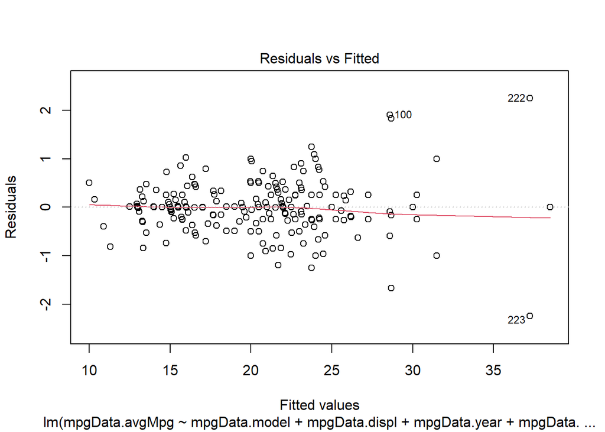

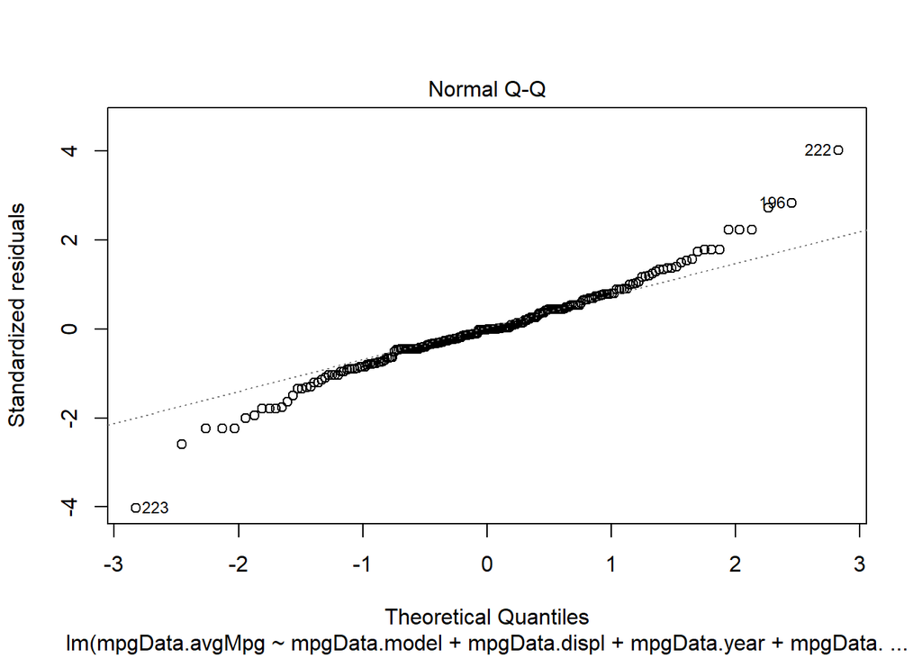

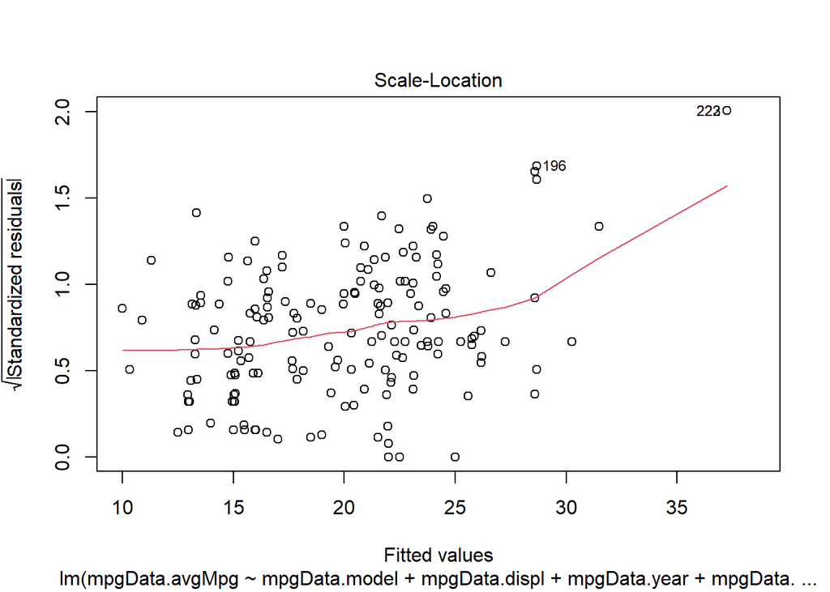

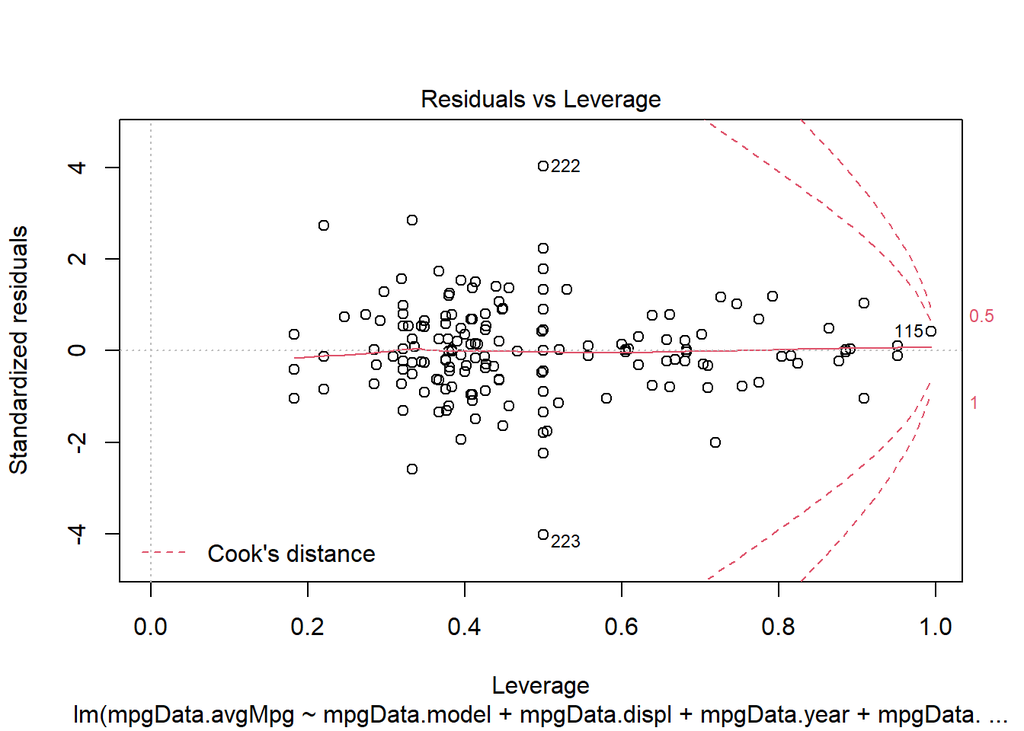

```r
plot(bestMainInteractionsEffects)
```

The model with interactions shares most of the same qualities as the intial model. R-squared and Adj-Rsquared are both higher, suggesting we explain more variance in the data which makes sense as our model is including the interaction effects of most of the categorical variables in our main model.

The first residuals grahp is even more linear with less clustering, and appears to have fewer outliers still making linear regression a good choce.

The QQ plot tails are less skewed and closer to our main line which suggests we’ve compensated for some of the skewed, non-linear effcts we were seeing when we did not include the interactions.

The Scale-Location graph has skewed even more, however. Suggesting greater heteroskedasticity than we saw in our initial model. Due to the size difference, we may have some underlying issues in our data and model selection that need to be addressed to make our predictions more precise.

Lastly, the residuals vs levereage plot l;ooks uch beter with all of the extreme values being pulled closer together with a shorter cook’s distance and having a less extreme effect on our model overall.

### Question 1I

Most of our predictors have pretty small effects that when combined add up to a decent avgMPG. This is likely due to the relatively large number of factors in the categorical variables, each having a small effect that adds up once combined with teh other factors. The interactep suggests an avgMPG of less than 0, which is impossible, but once combined witht eh model, model interactions, displacement, year, fuel type, etc. we get a main effect. It looks like the base case is a 4 cylinder, using ‘c’ fuel, 4runner.